# model

Anshuman Dikhit & Precila Dessai

## Import libraries

```r
library(moments)
library(MASS)
library(car)
```

```r
library(ggplot2)
```

## Convert cumulative counts to new counts

The data in our current datasets currently displays a cumulative count of confirmed cases for each progressive day. This is not what we want. We need the number of NEW Cases in a single day

```r
# create a list of data frames
file_names = list.files(path = './JHU-COVID-19/csse_covid_19_data/csse_covid_19_daily_reports_us/', pattern = '*.csv')
file_paths = file.path('./JHU-COVID-19/csse_covid_19_data/csse_covid_19_daily_reports_us', file_names)
df_list = lapply(file_paths, read.csv)
# filter out US territories
df_list = lapply(df_list, FUN = function(df) { df[(df$Province_State %in% state.name), ]})

# calculate new cases
num_files = length(df_list)
for(i in 2:num_files) {
  df_list[[i]]$New_Cases = df_list[[i]]$Confirmed - df_list[[i - 1]]$Confirmed
  if(i == 2)
    df_list[[i]]$Yesterdays_Cases = 0
  else
    df_list[[i]]$Yesterdays_Cases = df_list[[i - 1]]$New_Cases
}
# in order to keep all of our data consistent, we must drop the first day's data - it is the only one with an aggregate count
df_list = df_list[2:length(df_list)]
```

## Merge Data

We will be merging data from all days into one dataset. Afterwards, we will rearrange the the data so that all state observations are placed together

```r
us_data = do.call(rbind, df_list)
drops = c('Last_Update','Lat', 'Long_', 'Confirmed', 'Deaths', 'Recovered', 'Active', 'FIPS', 'Incident_Rate', 'People_Tested', 'People_Hospitalized', 'Mortality_Rate', 'UID', 'ISO3')
us_data = us_data[, !(names(us_data) %in% drops)]
us_data = us_data[complete.cases(us_data), ]

state_df_list = list()
for(i in 1:50) {
  state_df = us_data[us_data$Province_State == state.name[i], ]
  if(nrow(state_df) == 0)
    next
  state_df = state_df[, !(names(state_df) %in% drops)]
  state_df$Country_Region = state.region[match(state_df$Province_State, state.name)]
  num_splits = ceiling(nrow(state_df)/7)
  splits_list = list()
  for(j in 1:num_splits) {
    start_idx = 7 * (j - 1) + 1
    end_idx = 7 * j
    split_df = state_df[start_idx:min(end_idx, nrow(state_df)), ]
    split_df = aggregate(split_df[,3:ncol(split_df)], split_df[,1:2], FUN = mean)
    splits_list[[j]] = split_df
  }
  state_df =  do.call(rbind, splits_list)
  state_df_list[[i]] = state_df
}
us_data = do.call(rbind, state_df_list)
col_names = c("State", "Region", "Avg_Tst_Rate", "Avg_Hsp_Rate", "Avg_Wkly_NC", "Avg_Cases_LW")
colnames(us_data) = col_names
head(us_data)
```

```
##     State Region Avg_Tst_Rate Avg_Hsp_Rate Avg_Wkly_NC Avg_Cases_LW
## 1 Alabama  South     788.6869     12.79825  189.285714     164.1429
## 2 Alabama  South    1199.2190     13.11888  219.000000     187.7143
## 3 Alabama  South    1810.0845     13.52619  209.571429     226.4286
## 4 Alabama  South    2460.5269     12.95506  285.857143     293.8571
## 5 Alabama  South    2836.7297     12.32169  270.333333     265.3333
## 6  Alaska   West    1495.5393     11.67440    6.714286       6.0000
```

## Perform necessary transformations

Next step is to ensure we uphold the assumption of normality across our continuous explanatory variables. This includes testing and transforming any variables necessary.

Testing of our continuous explanatory variables will be done by performing 3 tests:

1. Visual analysis of a histogram of our explanatory variable
2. Visual analysis of a Normal QQ-plot of our explanatory variable
3. Calculation of skewness and kurtosis of our explanatory variable

### Test normality of Testing Rate

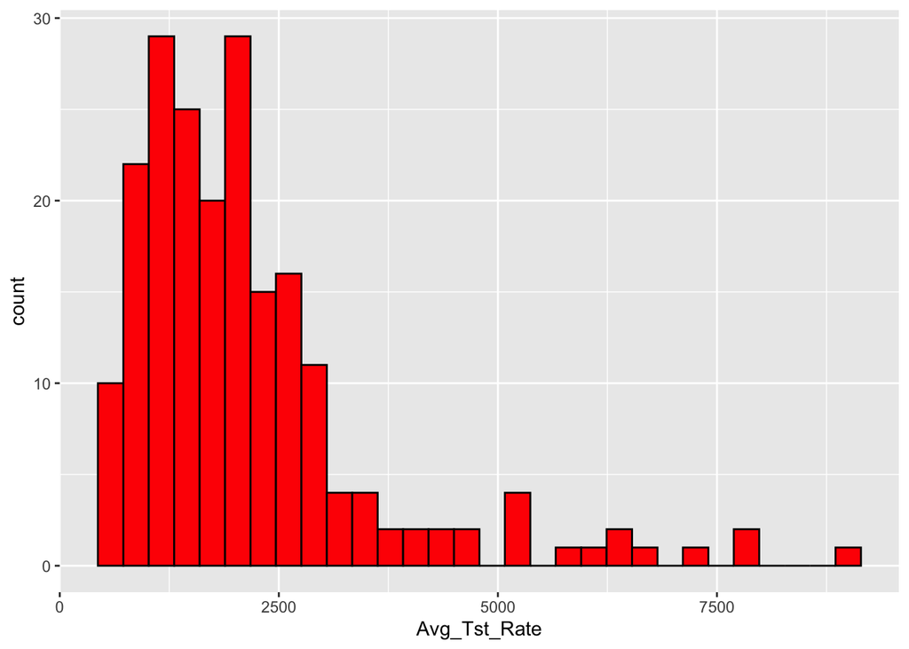

```r
# normality of testing rate
ggplot(us_data, aes(x = Avg_Tst_Rate)) + geom_histogram(color = "black", fill = "red")
```

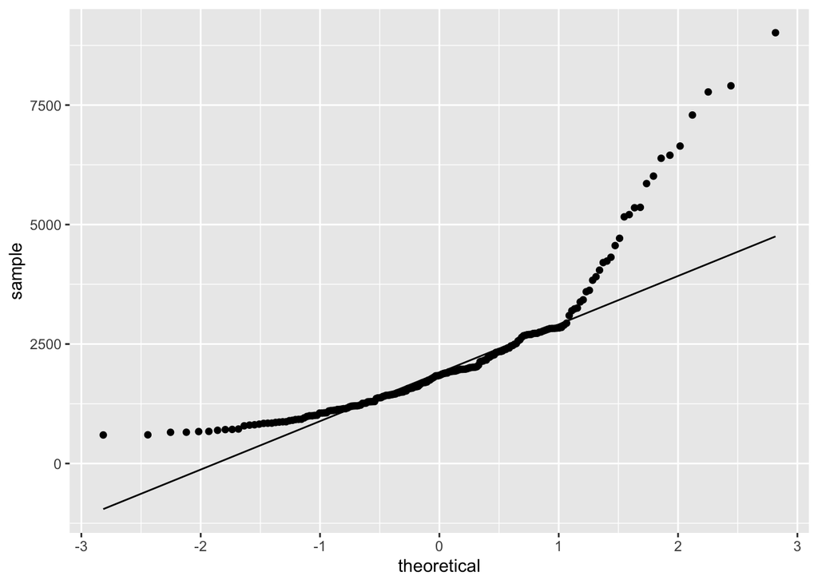

```r
ggplot(us_data, aes(sample = Avg_Tst_Rate)) + stat_qq() + stat_qq_line()
```

```r
skewness(us_data$Avg_Tst_Rate)
```

```
## [1] 2.142462
```

```r
kurtosis(us_data$Avg_Tst_Rate)
```

```
## [1] 8.409768
```

Our histogram shows a strong right skew, our qq plot is not at all linear and our skewness and kurtosis values are far greater than 0 and 3. We will try to normalize it via a log transformation.

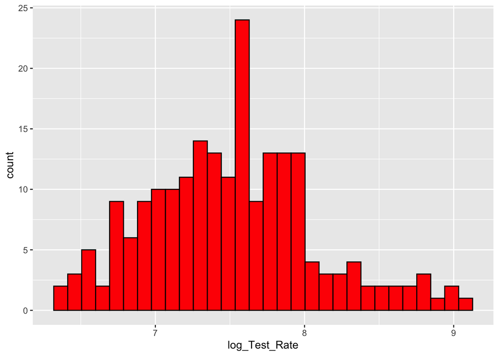

```r
# normality test for log transformed Testing Rate
us_data$log_Test_Rate = log(us_data$Avg_Tst_Rate)
ggplot(us_data, aes(x = log_Test_Rate)) + geom_histogram(color = "black", fill = "red")
```

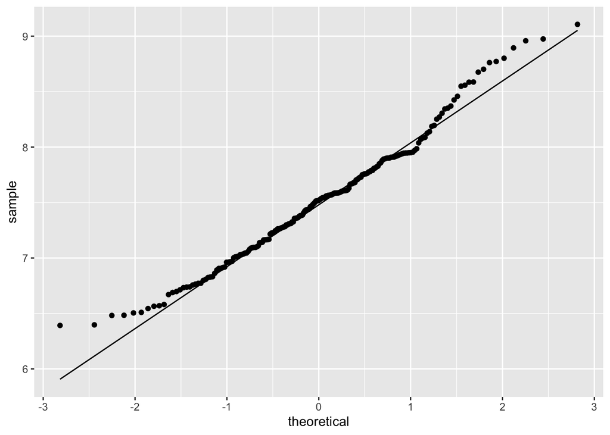

```r
ggplot(us_data, aes(sample = log_Test_Rate)) + stat_qq() + stat_qq_line()
```

```r
skewness(us_data$log_Test_Rate)
```

```
## [1] 0.4036254
```

```r
kurtosis(us_data$log_Test_Rate)
```

```
## [1] 3.054233
```

### Test normality of Hospitalization Rate

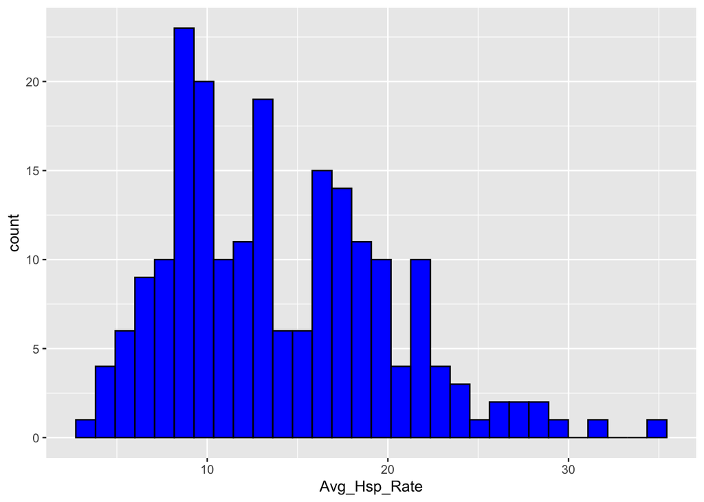

```r
ggplot(us_data, aes(x = Avg_Hsp_Rate)) + geom_histogram(color = "black", fill = "blue")
```

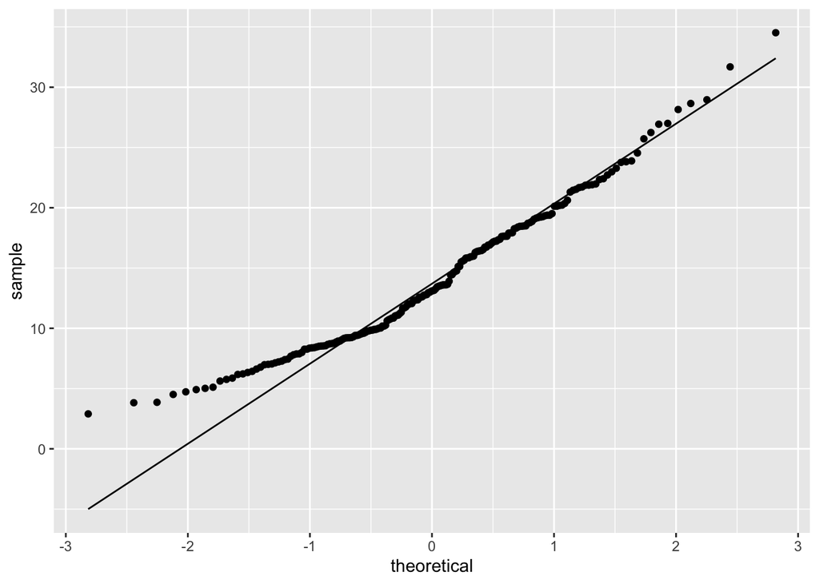

```r
ggplot(us_data, aes(sample = Avg_Hsp_Rate)) + stat_qq() + stat_qq_line()
```

```r
skewness(us_data$Avg_Hsp_Rate)
```

```
## [1] 0.6162561
```

```r
kurtosis(us_data$Avg_Hsp_Rate)
```

```
## [1] 3.071156
```

## Standardization

Due to the log transformation of one of our explanatory variables, the ranges of our explanatory variables has been completely modified. We will standardize our explanatory variables to combat this.

```r
mean_hsp_rate = mean(us_data$Avg_Hsp_Rate)
sd_hsp_rate = sd(us_data$Avg_Hsp_Rate)

mean_log_Test_Rate = mean(us_data$log_Test_Rate)
sd_log_Test_Rate = sd(us_data$log_Test_Rate)

us_data$std_hsp_rate = (us_data$Avg_Hsp_Rate - mean_hsp_rate)/sd_hsp_rate
us_data$std_log_Test_Rate = (us_data$log_Test_Rate - mean_log_Test_Rate)/sd_log_Test_Rate
head(us_data)
```

```
##     State Region Avg_Tst_Rate Avg_Hsp_Rate Avg_Wkly_NC Avg_Cases_LW
## 1 Alabama  South     788.6869     12.79825  189.285714     164.1429
## 2 Alabama  South    1199.2190     13.11888  219.000000     187.7143
## 3 Alabama  South    1810.0845     13.52619  209.571429     226.4286
## 4 Alabama  South    2460.5269     12.95506  285.857143     293.8571
## 5 Alabama  South    2836.7297     12.32169  270.333333     265.3333
## 6  Alaska   West    1495.5393     11.67440    6.714286       6.0000
##   log_Test_Rate std_hsp_rate std_log_Test_Rate
## 1      6.670369  -0.20260534        -1.5081461
## 2      7.089426  -0.14878244        -0.7552737
## 3      7.501129  -0.08040894        -0.0156123
## 4      7.808131  -0.17628194         0.5359442
## 5      7.950407  -0.28260337         0.7915564
## 6      7.310242  -0.39126045        -0.3585573
```

## Check for Multicollinnearity

Before we perform any transformations or build any models, we will test our continuous explanatory variables for multicollinearity

```r
vif(lm(Avg_Wkly_NC ~ Region + Avg_Tst_Rate + Avg_Hsp_Rate + Avg_Cases_LW, data = us_data))
```

```
##                  GVIF Df GVIF^(1/(2*Df))
## Region       1.413286  3        1.059347
## Avg_Tst_Rate 1.159638  1        1.076865
## Avg_Hsp_Rate 1.084565  1        1.041424
## Avg_Cases_LW 1.269886  1        1.126892
```

All of our explanatory variables have Variance Inflation Factors with values less than 10 - there is no multicollinearity within our model.

## Cross Validation

Since our question is not one of prediction, but of inference, we do not need to test the accuracy of our model against future data. Rather we should be testing its accuracy against our current observed values (this can be done by calculating the RMSE).

## Train our model

### Create our Baseline model

Our first model will simply regress our Y variable (`Avg_Wkly_NC`) against our pre-determined explanatory variables (`Region`, `log_Test_Rate`, `Avg_Hsp_Rate`, and `Avg_Cases_LW`)

```r
first_model = lm(Avg_Wkly_NC ~ Region + std_log_Test_Rate + std_hsp_rate + Avg_Cases_LW, data = us_data)
summary(first_model)
```

```
##
## Call:
## lm(formula = Avg_Wkly_NC ~ Region + std_log_Test_Rate + std_hsp_rate +
##     Avg_Cases_LW, data = us_data)
##
## Residuals:
##      Min       1Q   Median       3Q      Max
## -1380.16   -16.22     3.76    32.83   808.61
##
## Coefficients:
##                      Estimate Std. Error t value Pr(>|t|)
## (Intercept)         -15.69955   29.77234  -0.527    0.599
## RegionSouth           6.10748   33.26066   0.184    0.854
## RegionNorth Central  12.87460   35.47892   0.363    0.717
## RegionWest           29.07388   34.71335   0.838    0.403
## std_log_Test_Rate   -15.68168   11.06788  -1.417    0.158
## std_hsp_rate         14.34204   10.76442   1.332    0.184
## Avg_Cases_LW          1.00997    0.01292  78.166   <2e-16 ***
## ---
## Signif. codes:  0 '***' 0.001 '**' 0.01 '*' 0.05 '.' 0.1 ' ' 1
##
## Residual standard error: 145.9 on 199 degrees of freedom
## Multiple R-squared:  0.9748, Adjusted R-squared:  0.9741
## F-statistic:  1286 on 6 and 199 DF,  p-value: < 2.2e-16
```

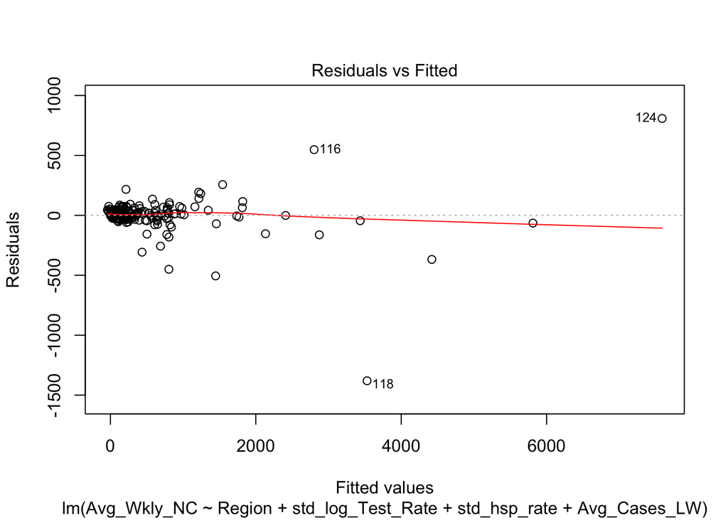

```r
plot(first_model, which = c(1))
```

All of our categorical variables have p values greater than 0.05 - meaning that the region of the United States adds nothing of significance to the calculation of this week’s average number of new cases. Since all of our categorical dummies are insignificant, we can remove the entire variable from our model.

```r
step_model = lm(Avg_Wkly_NC ~ std_log_Test_Rate + std_hsp_rate + Avg_Cases_LW, data = us_data)
summary(step_model)
```

```
##
## Call:
## lm(formula = Avg_Wkly_NC ~ std_log_Test_Rate + std_hsp_rate +
##     Avg_Cases_LW, data = us_data)
##
## Residuals:
##      Min       1Q   Median       3Q      Max
## -1382.26   -14.05     7.05    28.92   822.66
##
## Coefficients:
##                    Estimate Std. Error t value Pr(>|t|)
## (Intercept)        -1.49022   11.68802  -0.128    0.899
## std_log_Test_Rate -16.52361   10.66927  -1.549    0.123
## std_hsp_rate       13.71359   10.53923   1.301    0.195
## Avg_Cases_LW        1.00644    0.01169  86.084   <2e-16 ***
## ---
## Signif. codes:  0 '***' 0.001 '**' 0.01 '*' 0.05 '.' 0.1 ' ' 1
##
## Residual standard error: 145.2 on 202 degrees of freedom
## Multiple R-squared:  0.9747, Adjusted R-squared:  0.9743
## F-statistic:  2597 on 3 and 202 DF,  p-value: < 2.2e-16
```

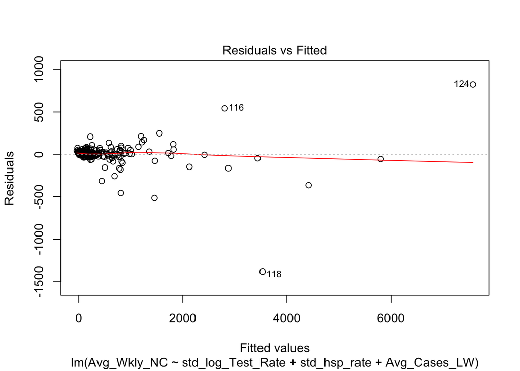

```r
plot(step_model, which = c(1))
```

```r
step_model = lm(Avg_Wkly_NC ~ std_hsp_rate + Avg_Cases_LW, data = us_data)
summary(step_model)
```

```
##
## Call:
## lm(formula = Avg_Wkly_NC ~ std_hsp_rate + Avg_Cases_LW, data = us_data)
##
## Residuals:
##      Min       1Q   Median       3Q      Max
## -1375.06   -16.62     5.99    25.35   826.35
##
## Coefficients:
##              Estimate Std. Error t value Pr(>|t|)
## (Intercept)   0.40046   11.66406   0.034   0.9726
## std_hsp_rate 17.90447   10.22093   1.752   0.0813 .
## Avg_Cases_LW  1.00267    0.01147  87.390   <2e-16 ***
## ---
## Signif. codes:  0 '***' 0.001 '**' 0.01 '*' 0.05 '.' 0.1 ' ' 1
##
## Residual standard error: 145.7 on 203 degrees of freedom
## Multiple R-squared:  0.9744, Adjusted R-squared:  0.9742
## F-statistic:  3867 on 2 and 203 DF,  p-value: < 2.2e-16
```

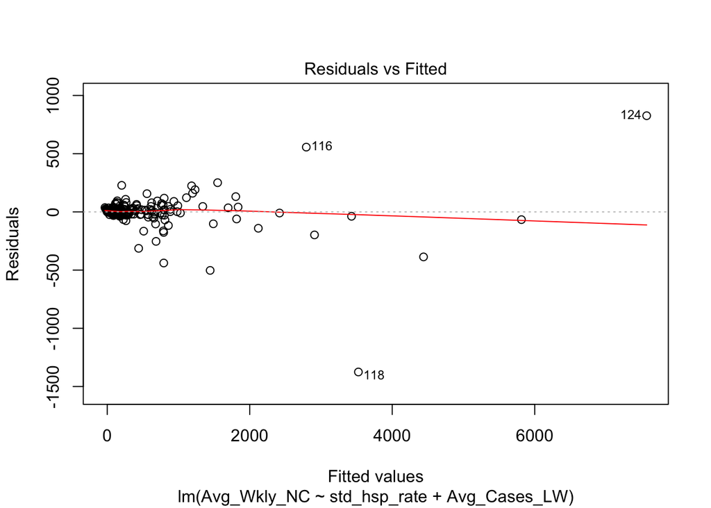

```r
plot(step_model, which = c(1))
```

## Testing Final Model

Now that we have our final model, we will test its accuracy by calculating out the RMSE of our model.

```r
y_hat = predict(step_model, newdata = us_data)
rmse = sqrt(mean((y_hat - us_data$Avg_Wkly_NC)^2))
mean(us_data$Avg_Wkly_NC)
```

```
## [1] 502.2083
```

```r
rmse
```

```
## [1] 144.6541
```

This additional scatterplot shows the fit of our predicted values against the observed values.

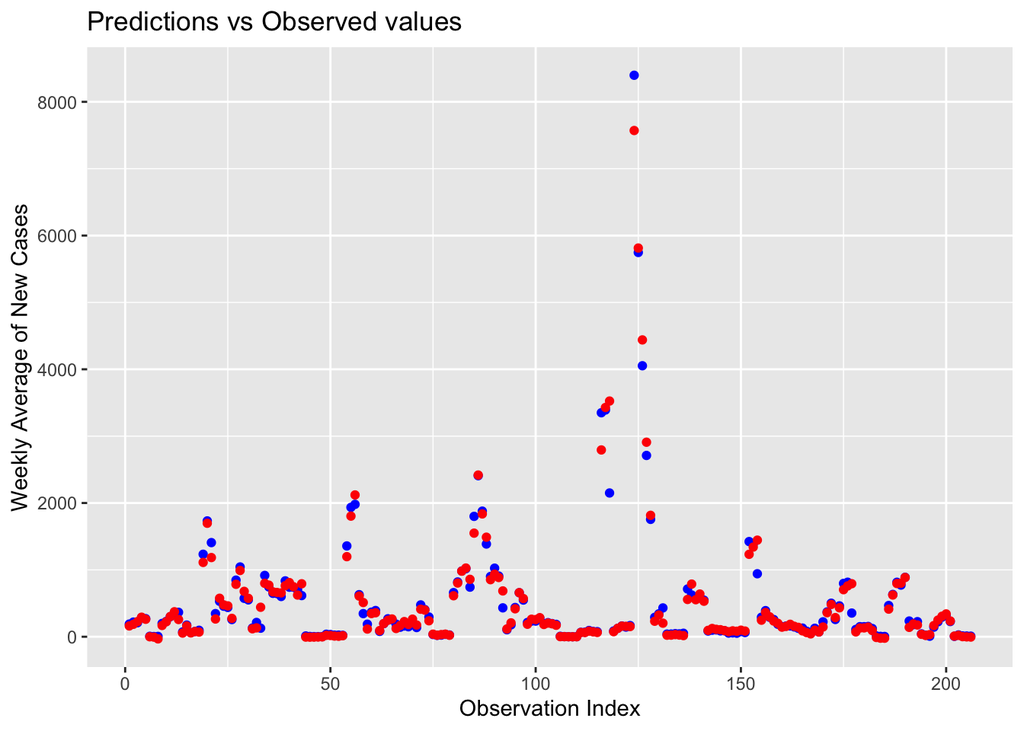

```r
accuracy_df = data.frame(cbind(y_hat, us_data$Avg_Wkly_NC))
ggplot(accuracy_df) +
  geom_point(aes(as.numeric(rownames(accuracy_df)), V2), color = 'blue') +
  geom_point(aes(as.numeric(rownames(accuracy_df)), y_hat), color = "red") +
  ggtitle('Predictions vs Observed values') + xlab('Observation Index') + ylab('Weekly Average of New Cases')
```